# Module 2 Diamonds Assignment

Jami Watson

2025-04-10

```r
summary(diamonds)
```

```
##      carat               cut        color        clarity          depth
##  Min.   :0.2000   Fair     : 1610   D: 6775   SI1    :13065   Min.   :43.00
##  1st Qu.:0.4000   Good     : 4906   E: 9797   VS2    :12258   1st Qu.:61.00
##  Median :0.7000   Very Good:12082   F: 9542   SI2    : 9194   Median :61.80
##  Mean   :0.7979   Premium  :13791   G:11292   VS1    : 8171   Mean   :61.75
##  3rd Qu.:1.0400   Ideal    :21551   H: 8304   VVS2   : 5066   3rd Qu.:62.50
##  Max.   :5.0100                     I: 5422   VVS1   : 3655   Max.   :79.00
##                                     J: 2808   (Other): 2531
##      table           price             x                y
##  Min.   :43.00   Min.   :  326   Min.   : 0.000   Min.   : 0.000
##  1st Qu.:56.00   1st Qu.:  950   1st Qu.: 4.710   1st Qu.: 4.720
##  Median :57.00   Median : 2401   Median : 5.700   Median : 5.710
##  Mean   :57.46   Mean   : 3933   Mean   : 5.731   Mean   : 5.735
##  3rd Qu.:59.00   3rd Qu.: 5324   3rd Qu.: 6.540   3rd Qu.: 6.540
##  Max.   :95.00   Max.   :18823   Max.   :10.740   Max.   :58.900
##
##        z
##  Min.   : 0.000
##  1st Qu.: 2.910
##  Median : 3.530
##  Mean   : 3.539
##  3rd Qu.: 4.040
##  Max.   :31.800
##
```

Null hypothesis- True mean is equivalent to 1 carat. Alternative hypothesis- True mean is not equivalent to 1 carat.

To run a bootstrap mean we will first install the boot package from the library.

```r
library(boot)
```

Then we assign our function the name, boot_mean

```r
boot_mean <- function(df, indices) {
  return(mean(df[indices]))
}
```

We then pick a random number for the set.seed and create our bootstrap samples and run our statistic on them.

```r
set.seed(65)
bootstrap_results <- boot(diamonds$carat, boot_mean, R = 1001)
print(bootstrap_results)
```

```
##
## ORDINARY NONPARAMETRIC BOOTSTRAP
##
##
## Call:
## boot(data = diamonds$carat, statistic = boot_mean, R = 1001)
##
##
## Bootstrap Statistics :
##      original        bias    std. error
## t1* 0.7979397 -1.146221e-05  0.00205968
```

We can see that our original mean statistic was 0.798, and our bootstrap was not far off from that, -0.00001146 away. Now to see the distribution of our boostrap we will create a histogram of the test statistics ran on that bootstrap samples.

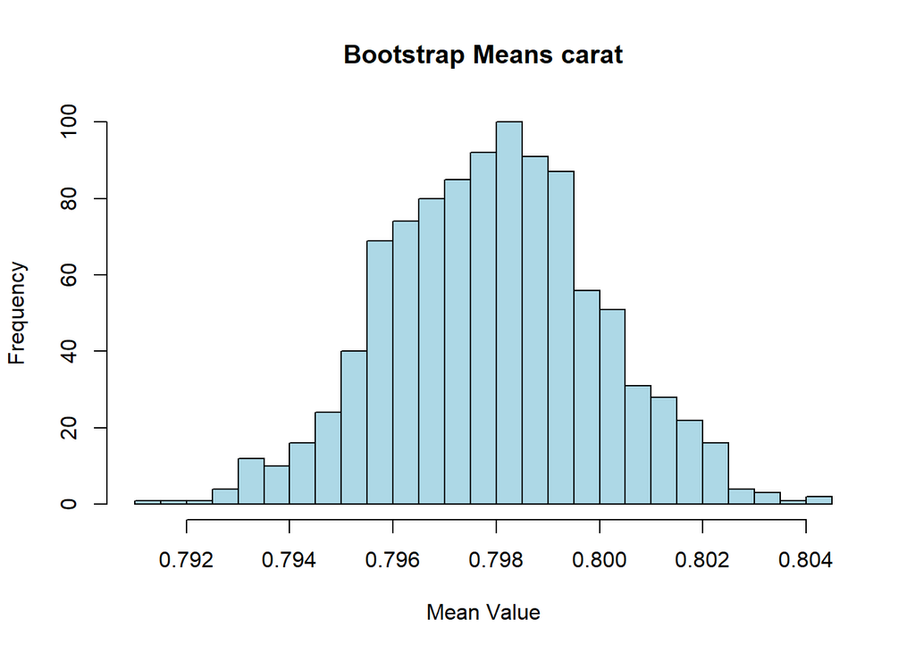

```r
hist(bootstrap_results$t, breaks = 30, main = "Bootstrap Means carat", xlab = "Mean Value", col = "lightblue", border = "black")
```

We are given a relatively normal distribution. We will now find the bootstrap confidence interval and see if your null hypothesis is true.

```r
boot.ci(bootstrap_results, type = c("perc"))
```

```
## BOOTSTRAP CONFIDENCE INTERVAL CALCULATIONS
## Based on 1001 bootstrap replicates
##
## CALL :
## boot.ci(boot.out = bootstrap_results, type = c("perc"))
##
## Intervals :
## Level     Percentile
## 95%   ( 0.7938,  0.8020 )
## Calculations and Intervals on Original Scale
```

Our null hypothesis of the true mean being 1 carat is rejected because it does not lie within our 95% confidence interval. Thus, the true mean is not equivalent to 1 carat.

Now for 10 fold cross validations First we will install the caret package, and then we will randomly select 2/3 of our data to be our training data.

```r
library(caret)
trainingsample <- createDataPartition(diamonds$carat +diamonds$depth + diamonds$table, p=0.667,list=FALSE)
```

We will now assign this 2/3 of the data to traindata, and the remaining 1/3 of the data to testdata.

```r
traindata <- diamonds[trainingsample, ]
testdata <- diamonds[-trainingsample, ]
```

Here is the linear model summary of all of our data.

```r
fit <- lm(price ~ carat +depth + table, data = diamonds)
summary(fit)
```

```
##
## Call:
## lm(formula = price ~ carat + depth + table, data = diamonds)
##
## Residuals:
##      Min       1Q   Median       3Q      Max
## -18288.0   -785.9    -33.2    527.2  12486.7
##
## Coefficients:
##              Estimate Std. Error t value Pr(>|t|)
## (Intercept) 13003.441    390.918   33.26   <2e-16 ***
## carat        7858.771     14.151  555.36   <2e-16 ***
## depth        -151.236      4.820  -31.38   <2e-16 ***
## table        -104.473      3.141  -33.26   <2e-16 ***
## ---
## Signif. codes:  0 '***' 0.001 '**' 0.01 '*' 0.05 '.' 0.1 ' ' 1
##
## Residual standard error: 1526 on 53936 degrees of freedom
## Multiple R-squared:  0.8537, Adjusted R-squared:  0.8537
## F-statistic: 1.049e+05 on 3 and 53936 DF,  p-value: < 2.2e-16
```

Here is the linear model summary of just our traindata.

```r
fit <- lm(price ~ carat +depth + table, data = traindata)
summary(fit)
```

```
##
## Call:
## lm(formula = price ~ carat + depth + table, data = traindata)
##
## Residuals:
##      Min       1Q   Median       3Q      Max
## -18407.8   -782.8    -31.1    532.2  12476.9
##
## Coefficients:
##              Estimate Std. Error t value Pr(>|t|)
## (Intercept) 12979.690    477.753   27.17   <2e-16 ***
## carat        7886.105     17.321  455.28   <2e-16 ***
## depth        -149.865      5.868  -25.54   <2e-16 ***
## table        -105.883      3.851  -27.49   <2e-16 ***
## ---
## Signif. codes:  0 '***' 0.001 '**' 0.01 '*' 0.05 '.' 0.1 ' ' 1
##
## Residual standard error: 1524 on 35975 degrees of freedom
## Multiple R-squared:  0.8547, Adjusted R-squared:  0.8547
## F-statistic: 7.056e+04 on 3 and 35975 DF,  p-value: < 2.2e-16
```

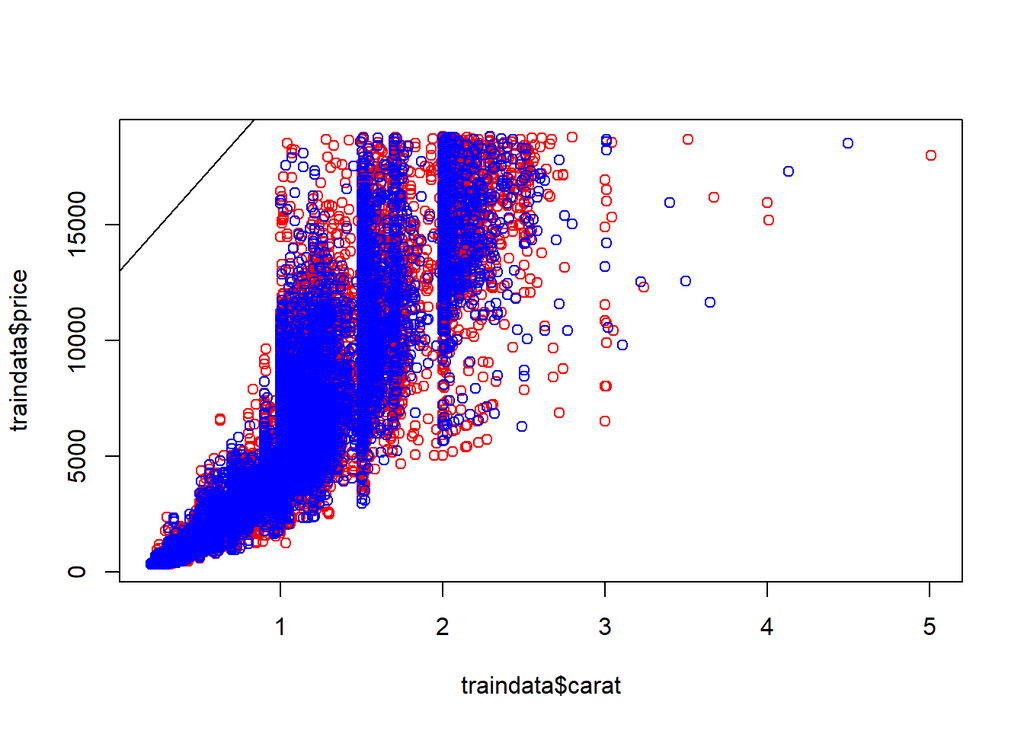

```r
plot(traindata$carat,traindata$price,col="red")
points(testdata$carat,testdata$price,col="blue")
abline(fit)
```

Disregard this for now, need to work out a few kinks but I am keeping it in here to remind myself to ask questions later.

```r
pre <- predict(fit, testdata)
```

```r
R2(pre, testdata$price)
```

```
## [1] 0.8515788
```

I believe this is our predicted R-squared value, pretty close to our train and original data. Also shows a good fit.

```r
train.control <- trainControl(method="cv", number=10)
model <- train(price~carat + depth + table,
               data=diamonds,
               method='lm',
               trControl=train.control)
print(model)
```

```
## Linear Regression
##
## 53940 samples
##     3 predictor
##
## No pre-processing
## Resampling: Cross-Validated (10 fold)
## Summary of sample sizes: 48546, 48546, 48546, 48546, 48546, 48546, ...
## Resampling results:
##
##   RMSE      Rsquared   MAE
##   1525.681  0.8537729  994.4305
##
## Tuning parameter 'intercept' was held constant at a value of TRUE
```